# Project Title

```python
temperature_table[temperature_table['City']=='Louisville']
```

|  | dt | AverageTemperature | AverageTemperatureUncertainty | City | Country | Latitude | Longitude | month |
| --- | --- | --- | --- | --- | --- | --- | --- | --- |
| 4372245 | 1986-01-01 | 0.872 | 0.262 | Louisville | United States | 37.78 | -85.42 | 1 |
| 4372246 | 1986-02-01 | 4.549 | 0.316 | Louisville | United States | 37.78 | -85.42 | 2 |
| 4372247 | 1986-03-01 | 8.675 | 0.299 | Louisville | United States | 37.78 | -85.42 | 3 |
| 4372248 | 1986-04-01 | 14.489 | 0.238 | Louisville | United States | 37.78 | -85.42 | 4 |
| 4372249 | 1986-05-01 | 19.376 | 0.317 | Louisville | United States | 37.78 | -85.42 | 5 |
| 4372250 | 1986-06-01 | 23.822 | 0.317 | Louisville | United States | 37.78 | -85.42 | 6 |
| 4372251 | 1986-07-01 | 26.583 | 0.347 | Louisville | United States | 37.78 | -85.42 | 7 |
| 4372252 | 1986-08-01 | 23.041 | 0.315 | Louisville | United States | 37.78 | -85.42 | 8 |
| 4372253 | 1986-09-01 | 22.275 | 0.236 | Louisville | United States | 37.78 | -85.42 | 9 |
| 4372254 | 1986-10-01 | 14.789 | 0.209 | Louisville | United States | 37.78 | -85.42 | 10 |
| 4372255 | 1986-11-01 | 7.853 | 0.271 | Louisville | United States | 37.78 | -85.42 | 11 |
| 4372256 | 1986-12-01 | 2.523 | 0.170 | Louisville | United States | 37.78 | -85.42 | 12 |
| 4372257 | 1987-01-01 | 0.508 | 0.366 | Louisville | United States | 37.78 | -85.42 | 1 |
| 4372258 | 1987-02-01 | 4.009 | 0.287 | Louisville | United States | 37.78 | -85.42 | 2 |
| 4372259 | 1987-03-01 | 8.978 | 0.248 | Louisville | United States | 37.78 | -85.42 | 3 |
| 4372260 | 1987-04-01 | 12.341 | 0.202 | Louisville | United States | 37.78 | -85.42 | 4 |
| 4372261 | 1987-05-01 | 21.480 | 0.249 | Louisville | United States | 37.78 | -85.42 | 5 |
| 4372262 | 1987-06-01 | 24.147 | 0.225 | Louisville | United States | 37.78 | -85.42 | 6 |
| 4372263 | 1987-07-01 | 25.475 | 0.219 | Louisville | United States | 37.78 | -85.42 | 7 |
| 4372264 | 1987-08-01 | 25.417 | 0.188 | Louisville | United States | 37.78 | -85.42 | 8 |
| 4372265 | 1987-09-01 | 20.941 | 0.421 | Louisville | United States | 37.78 | -85.42 | 9 |
| 4372266 | 1987-10-01 | 10.806 | 0.393 | Louisville | United States | 37.78 | -85.42 | 10 |
| 4372267 | 1987-11-01 | 10.217 | 0.278 | Louisville | United States | 37.78 | -85.42 | 11 |
| 4372268 | 1987-12-01 | 4.277 | 0.238 | Louisville | United States | 37.78 | -85.42 | 12 |
| 4372269 | 1988-01-01 | -0.820 | 0.226 | Louisville | United States | 37.78 | -85.42 | 1 |
| 4372270 | 1988-02-01 | 1.617 | 0.189 | Louisville | United States | 37.78 | -85.42 | 2 |
| 4372271 | 1988-03-01 | 7.492 | 0.326 | Louisville | United States | 37.78 | -85.42 | 3 |
| 4372272 | 1988-04-01 | 12.958 | 0.335 | Louisville | United States | 37.78 | -85.42 | 4 |
| 4372273 | 1988-05-01 | 18.228 | 0.287 | Louisville | United States | 37.78 | -85.42 | 5 |
| 4372274 | 1988-06-01 | 23.297 | 0.303 | Louisville | United States | 37.78 | -85.42 | 6 |

[output cut: 303 more lines]

```python
temperature_table[temperature_table['City']=='Lexington Fayette']
```

|  | dt | AverageTemperature | AverageTemperatureUncertainty | City | Country | Latitude | Longitude | month |
| --- | --- | --- | --- | --- | --- | --- | --- | --- |
| 4235845 | 1986-01-01 | 0.872 | 0.262 | Lexington Fayette | United States | 37.78 | -85.42 | 1 |
| 4235846 | 1986-02-01 | 4.549 | 0.316 | Lexington Fayette | United States | 37.78 | -85.42 | 2 |
| 4235847 | 1986-03-01 | 8.675 | 0.299 | Lexington Fayette | United States | 37.78 | -85.42 | 3 |
| 4235848 | 1986-04-01 | 14.489 | 0.238 | Lexington Fayette | United States | 37.78 | -85.42 | 4 |
| 4235849 | 1986-05-01 | 19.376 | 0.317 | Lexington Fayette | United States | 37.78 | -85.42 | 5 |
| 4235850 | 1986-06-01 | 23.822 | 0.317 | Lexington Fayette | United States | 37.78 | -85.42 | 6 |
| 4235851 | 1986-07-01 | 26.583 | 0.347 | Lexington Fayette | United States | 37.78 | -85.42 | 7 |
| 4235852 | 1986-08-01 | 23.041 | 0.315 | Lexington Fayette | United States | 37.78 | -85.42 | 8 |
| 4235853 | 1986-09-01 | 22.275 | 0.236 | Lexington Fayette | United States | 37.78 | -85.42 | 9 |
| 4235854 | 1986-10-01 | 14.789 | 0.209 | Lexington Fayette | United States | 37.78 | -85.42 | 10 |
| 4235855 | 1986-11-01 | 7.853 | 0.271 | Lexington Fayette | United States | 37.78 | -85.42 | 11 |
| 4235856 | 1986-12-01 | 2.523 | 0.170 | Lexington Fayette | United States | 37.78 | -85.42 | 12 |
| 4235857 | 1987-01-01 | 0.508 | 0.366 | Lexington Fayette | United States | 37.78 | -85.42 | 1 |
| 4235858 | 1987-02-01 | 4.009 | 0.287 | Lexington Fayette | United States | 37.78 | -85.42 | 2 |
| 4235859 | 1987-03-01 | 8.978 | 0.248 | Lexington Fayette | United States | 37.78 | -85.42 | 3 |
| 4235860 | 1987-04-01 | 12.341 | 0.202 | Lexington Fayette | United States | 37.78 | -85.42 | 4 |
| 4235861 | 1987-05-01 | 21.480 | 0.249 | Lexington Fayette | United States | 37.78 | -85.42 | 5 |
| 4235862 | 1987-06-01 | 24.147 | 0.225 | Lexington Fayette | United States | 37.78 | -85.42 | 6 |
| 4235863 | 1987-07-01 | 25.475 | 0.219 | Lexington Fayette | United States | 37.78 | -85.42 | 7 |
| 4235864 | 1987-08-01 | 25.417 | 0.188 | Lexington Fayette | United States | 37.78 | -85.42 | 8 |
| 4235865 | 1987-09-01 | 20.941 | 0.421 | Lexington Fayette | United States | 37.78 | -85.42 | 9 |
| 4235866 | 1987-10-01 | 10.806 | 0.393 | Lexington Fayette | United States | 37.78 | -85.42 | 10 |
| 4235867 | 1987-11-01 | 10.217 | 0.278 | Lexington Fayette | United States | 37.78 | -85.42 | 11 |
| 4235868 | 1987-12-01 | 4.277 | 0.238 | Lexington Fayette | United States | 37.78 | -85.42 | 12 |
| 4235869 | 1988-01-01 | -0.820 | 0.226 | Lexington Fayette | United States | 37.78 | -85.42 | 1 |
| 4235870 | 1988-02-01 | 1.617 | 0.189 | Lexington Fayette | United States | 37.78 | -85.42 | 2 |
| 4235871 | 1988-03-01 | 7.492 | 0.326 | Lexington Fayette | United States | 37.78 | -85.42 | 3 |
| 4235872 | 1988-04-01 | 12.958 | 0.335 | Lexington Fayette | United States | 37.78 | -85.42 | 4 |
| 4235873 | 1988-05-01 | 18.228 | 0.287 | Lexington Fayette | United States | 37.78 | -85.42 | 5 |
| 4235874 | 1988-06-01 | 23.297 | 0.303 | Lexington Fayette | United States | 37.78 | -85.42 | 6 |

[output cut: 303 more lines]

```python
temperature_table.head()
```

|  | dt | AverageTemperature | AverageTemperatureUncertainty | City | Country | Latitude | Longitude | month |
| --- | --- | --- | --- | --- | --- | --- | --- | --- |
| 2906 | 1986-01-01 | -1.778 | 0.399 | Århus | Denmark | 57.05 | -10.33 | 1 |
| 2907 | 1986-02-01 | -4.655 | 0.315 | Århus | Denmark | 57.05 | -10.33 | 2 |
| 2908 | 1986-03-01 | 1.774 | 0.401 | Århus | Denmark | 57.05 | -10.33 | 3 |
| 2909 | 1986-04-01 | 4.243 | 0.191 | Århus | Denmark | 57.05 | -10.33 | 4 |
| 2910 | 1986-05-01 | 11.478 | 0.414 | Århus | Denmark | 57.05 | -10.33 | 5 |

```python
# calculate the mean of city's temperature of each month
temperature_table_month=temperature_table.groupby(['Country','City','month','Latitude','Longitude'],as_index=False)['AverageTemperature'].mean().round(3)
temperature_table_month.head(20)
```

|  | Country | City | month | Latitude | Longitude | AverageTemperature |
| --- | --- | --- | --- | --- | --- | --- |
| 0 | Afghanistan | Baglan | 1 | 36.17 | -69.61 | -1.793 |
| 1 | Afghanistan | Baglan | 2 | 36.17 | -69.61 | 0.430 |
| 2 | Afghanistan | Baglan | 3 | 36.17 | -69.61 | 5.829 |
| 3 | Afghanistan | Baglan | 4 | 36.17 | -69.61 | 11.718 |
| 4 | Afghanistan | Baglan | 5 | 36.17 | -69.61 | 17.412 |
| 5 | Afghanistan | Baglan | 6 | 36.17 | -69.61 | 22.619 |
| 6 | Afghanistan | Baglan | 7 | 36.17 | -69.61 | 24.685 |
| 7 | Afghanistan | Baglan | 8 | 36.17 | -69.61 | 23.330 |
| 8 | Afghanistan | Baglan | 9 | 36.17 | -69.61 | 18.704 |
| 9 | Afghanistan | Baglan | 10 | 36.17 | -69.61 | 12.031 |
| 10 | Afghanistan | Baglan | 11 | 36.17 | -69.61 | 5.928 |
| 11 | Afghanistan | Baglan | 12 | 36.17 | -69.61 | 0.416 |
| 12 | Afghanistan | Gardez | 1 | 32.95 | -69.89 | 5.922 |
| 13 | Afghanistan | Gardez | 2 | 32.95 | -69.89 | 7.845 |
| 14 | Afghanistan | Gardez | 3 | 32.95 | -69.89 | 12.956 |
| 15 | Afghanistan | Gardez | 4 | 32.95 | -69.89 | 18.731 |
| 16 | Afghanistan | Gardez | 5 | 32.95 | -69.89 | 24.487 |
| 17 | Afghanistan | Gardez | 6 | 32.95 | -69.89 | 27.736 |
| 18 | Afghanistan | Gardez | 7 | 32.95 | -69.89 | 28.057 |
| 19 | Afghanistan | Gardez | 8 | 32.95 | -69.89 | 26.964 |

```python
temperature_table_month = temperature_table_month.reset_index()
temperature_table_month.rename(columns = {'index':'temperature_id'}, inplace = True)
```

```python
temperature_table_month.head()
```

|  | temperature_id | Country | City | month | Latitude | Longitude | AverageTemperature |
| --- | --- | --- | --- | --- | --- | --- | --- |
| 0 | 0 | Afghanistan | Baglan | 1 | 36.17 | -69.61 | -1.793 |
| 1 | 1 | Afghanistan | Baglan | 2 | 36.17 | -69.61 | 0.430 |
| 2 | 2 | Afghanistan | Baglan | 3 | 36.17 | -69.61 | 5.829 |
| 3 | 3 | Afghanistan | Baglan | 4 | 36.17 | -69.61 | 11.718 |
| 4 | 4 | Afghanistan | Baglan | 5 | 36.17 | -69.61 | 17.412 |

```python
temperature_table_month.to_csv('transformed/temperature_table_month.csv',index=False)
```

```python
temperature_table_month = pd.read_csv('transformed/temperature_table_month.csv')
```

```python
test_temperature = temperature_table_month[temperature_table_month['Country']=='United States']
```

```python
temperature_table_month[temperature_table_month['Latitude']==37.78]
```

|  | temperature_id | Country | City | month | Latitude | Longitude | AverageTemperature |
| --- | --- | --- | --- | --- | --- | --- | --- |
| 396 | 396 | Argentina | Mar Del Plata | 1 | 37.78 | -56.95 | 20.662 |
| 397 | 397 | Argentina | Mar Del Plata | 2 | 37.78 | -56.95 | 20.390 |
| 398 | 398 | Argentina | Mar Del Plata | 3 | 37.78 | -56.95 | 19.565 |
| 399 | 399 | Argentina | Mar Del Plata | 4 | 37.78 | -56.95 | 16.618 |
| 400 | 400 | Argentina | Mar Del Plata | 5 | 37.78 | -56.95 | 14.080 |
| 401 | 401 | Argentina | Mar Del Plata | 6 | 37.78 | -56.95 | 11.831 |
| 402 | 402 | Argentina | Mar Del Plata | 7 | 37.78 | -56.95 | 10.903 |
| 403 | 403 | Argentina | Mar Del Plata | 8 | 37.78 | -56.95 | 11.927 |
| 404 | 404 | Argentina | Mar Del Plata | 9 | 37.78 | -56.95 | 12.667 |
| 405 | 405 | Argentina | Mar Del Plata | 10 | 37.78 | -56.95 | 14.710 |
| 406 | 406 | Argentina | Mar Del Plata | 11 | 37.78 | -56.95 | 17.062 |
| 407 | 407 | Argentina | Mar Del Plata | 12 | 37.78 | -56.95 | 19.083 |
| 612 | 612 | Argentina | Tandil | 1 | 37.78 | -58.98 | 22.178 |
| 613 | 613 | Argentina | Tandil | 2 | 37.78 | -58.98 | 21.191 |
| 614 | 614 | Argentina | Tandil | 3 | 37.78 | -58.98 | 19.155 |
| 615 | 615 | Argentina | Tandil | 4 | 37.78 | -58.98 | 14.918 |
| 616 | 616 | Argentina | Tandil | 5 | 37.78 | -58.98 | 11.342 |
| 617 | 617 | Argentina | Tandil | 6 | 37.78 | -58.98 | 8.509 |
| 618 | 618 | Argentina | Tandil | 7 | 37.78 | -58.98 | 7.645 |
| 619 | 619 | Argentina | Tandil | 8 | 37.78 | -58.98 | 9.527 |
| 620 | 620 | Argentina | Tandil | 9 | 37.78 | -58.98 | 11.492 |
| 621 | 621 | Argentina | Tandil | 10 | 37.78 | -58.98 | 14.541 |
| 622 | 622 | Argentina | Tandil | 11 | 37.78 | -58.98 | 17.753 |
| 623 | 623 | Argentina | Tandil | 12 | 37.78 | -58.98 | 20.476 |
| 744 | 744 | Australia | Geelong | 1 | 37.78 | -144.41 | 19.482 |
| 745 | 745 | Australia | Geelong | 2 | 37.78 | -144.41 | 19.668 |
| 746 | 746 | Australia | Geelong | 3 | 37.78 | -144.41 | 17.678 |
| 747 | 747 | Australia | Geelong | 4 | 37.78 | -144.41 | 14.345 |
| 748 | 748 | Australia | Geelong | 5 | 37.78 | -144.41 | 11.619 |
| 749 | 749 | Australia | Geelong | 6 | 37.78 | -144.41 | 9.308 |

[output cut: 1230 more lines]

```python
test_temperature[test_temperature['Country']=='United States']
```

|  | temperature_id | Country | City | month | Latitude | Longitude | AverageTemperature |
| --- | --- | --- | --- | --- | --- | --- | --- |
| 37980 | 37980 | United States | Antioch | 1 | 37.78 | -122.03 | 9.144 |
| 37981 | 37981 | United States | Antioch | 2 | 37.78 | -122.03 | 10.842 |
| 37982 | 37982 | United States | Antioch | 3 | 37.78 | -122.03 | 12.732 |
| 37983 | 37983 | United States | Antioch | 4 | 37.78 | -122.03 | 14.096 |
| 37984 | 37984 | United States | Antioch | 5 | 37.78 | -122.03 | 16.437 |
| 37985 | 37985 | United States | Antioch | 6 | 37.78 | -122.03 | 18.678 |
| 37986 | 37986 | United States | Antioch | 7 | 37.78 | -122.03 | 20.118 |
| 37987 | 37987 | United States | Antioch | 8 | 37.78 | -122.03 | 20.094 |
| 37988 | 37988 | United States | Antioch | 9 | 37.78 | -122.03 | 19.452 |
| 37989 | 37989 | United States | Antioch | 10 | 37.78 | -122.03 | 16.780 |
| 37990 | 37990 | United States | Antioch | 11 | 37.78 | -122.03 | 12.541 |
| 37991 | 37991 | United States | Antioch | 12 | 37.78 | -122.03 | 8.952 |
| 38136 | 38136 | United States | Berkeley | 1 | 37.78 | -122.03 | 9.144 |
| 38137 | 38137 | United States | Berkeley | 2 | 37.78 | -122.03 | 10.842 |
| 38138 | 38138 | United States | Berkeley | 3 | 37.78 | -122.03 | 12.732 |
| 38139 | 38139 | United States | Berkeley | 4 | 37.78 | -122.03 | 14.096 |
| 38140 | 38140 | United States | Berkeley | 5 | 37.78 | -122.03 | 16.437 |
| 38141 | 38141 | United States | Berkeley | 6 | 37.78 | -122.03 | 18.678 |
| 38142 | 38142 | United States | Berkeley | 7 | 37.78 | -122.03 | 20.118 |
| 38143 | 38143 | United States | Berkeley | 8 | 37.78 | -122.03 | 20.094 |
| 38144 | 38144 | United States | Berkeley | 9 | 37.78 | -122.03 | 19.452 |
| 38145 | 38145 | United States | Berkeley | 10 | 37.78 | -122.03 | 16.780 |
| 38146 | 38146 | United States | Berkeley | 11 | 37.78 | -122.03 | 12.541 |
| 38147 | 38147 | United States | Berkeley | 12 | 37.78 | -122.03 | 8.952 |
| 38460 | 38460 | United States | Concord | 1 | 37.78 | -122.03 | 9.144 |
| 38461 | 38461 | United States | Concord | 2 | 37.78 | -122.03 | 10.842 |
| 38462 | 38462 | United States | Concord | 3 | 37.78 | -122.03 | 12.732 |
| 38463 | 38463 | United States | Concord | 4 | 37.78 | -122.03 | 14.096 |
| 38464 | 38464 | United States | Concord | 5 | 37.78 | -122.03 | 16.437 |
| 38465 | 38465 | United States | Concord | 6 | 37.78 | -122.03 | 18.678 |

[output cut: 270 more lines]

```python
test_temperature['City'].value_counts()
```

```
Springfield          36
Peoria               24
Columbus             24
Aurora               24
Arlington            24
Glendale             24
Richmond             24
Pasadena             24
Paterson             12
Pembroke Pines       12
Pomona               12
Philadelphia         12
Phoenix              12
Paradise             12
Palmdale             12
Pittsburgh           12
Plano                12
Abilene              12
Portland             12
Port Saint Lucie     12
Overland Park        12
Providence           12
Provo                12
Pueblo               12
Raleigh              12
Rancho Cucamonga     12
Reno                 12
Rialto               12
Richardson           12
Riverside            12
Rochester            12
Rockford             12
Oxnard               12
Orange               12
Orlando              12
New York             12
Metairie             12
Miami                12
Milwaukee            12
Minneapolis          12
```

[output cut: 194 more lines]

```
Hollywood            12
Garland              12
Gilbert              12
Grand Prairie        12
Grand Rapids         12
Green Bay            12
Greensboro           12
Hampton              12
Hartford             12
Hayward              12
Henderson            12
Hialeah              12
Highlands Ranch      12
Yonkers              12
Name: City, dtype: int64
```

```python
temperature_table_month[temperature_table_month['City']=='Peoria']
```

[output not shown]

```python
airport_table[airport_table['municipality']=='Peoria']
```

[output not shown]

```python
temperature_table_month['Country'].value_counts()
```

```
India                                 4692
China                                 4560
United States                         3084
Brazil                                2640
Japan                                 2100
Russia                                1872
Indonesia                             1740
Mexico                                1164
Nigeria                               1092
Germany                                972
United Kingdom                         816
Iran                                   792
Philippines                            780
Pakistan                               708
Turkey                                 612
South Africa                           600
Spain                                  600
Italy                                  504
Venezuela                              480
Colombia                               468
Poland                                 456
France                                 432
Malaysia                               384
Argentina                              384
Taiwan                                 360
Vietnam                                360
Romania                                300
Canada                                 300
Chile                                  288
Netherlands                            288
Ukraine                                288
Congo (Democratic Republic Of The)     276
Peru                                   264
Thailand                               252
Burma                                  240
Bangladesh                             228
Egypt                                  228
Tanzania                               192
Kazakhstan                             180
Cameroon                               180
```

[output cut: 105 more lines]

```
Hong Kong                               12
Central African Republic                12
Papua New Guinea                        12
Singapore                               12
Djibouti                                12
Slovenia                                12
Oman                                    12
Cambodia                                12
South Korea                             12
Burundi                                 12
Eritrea                                 12
Suriname                                12
Swaziland                               12
Iceland                                 12
Name: Country, dtype: int64
```

```python
temperature_table_month.dtypes
```

[output not shown]

```python
df_demographic.count()
```

```
City                      2891
State                     2891
Median Age                2891
Male Population           2888
Female Population         2888
Total Population          2891
Number of Veterans        2878
Foreign-born              2878
Average Household Size    2875
State Code                2891
Race                      2891
Count                     2891
dtype: int64
```

```python
df_demographic.T.apply(lambda x: x.nunique(), axis=1)
```

```
City                       567
State                       49
Median Age                 180
Male Population            593
Female Population          594
Total Population           594
Number of Veterans         577
Foreign-born               587
Average Household Size     161
State Code                  49
Race                         5
Count                     2785
dtype: int64
```

```python
df_demographic['City'].value_counts()
```

```
Bloomington                                        15
Columbia                                           15
Springfield                                        15
Jackson                                            10
Norwalk                                            10
Lakewood                                           10
Arlington                                          10
Fayetteville                                       10
Rochester                                          10
Albany                                             10
Richmond                                           10
Aurora                                             10
Glendale                                           10
Union City                                         10
Wilmington                                         10
Pasadena                                           10
Portland                                           10
Westminster                                        10
Concord                                            10
Columbus                                           10
Peoria                                             10
Jacksonville                                       10
Allen                                              10
Kansas City                                        10
Lawrence                                            9
Lafayette                                           9
Iowa City                                           5
Saint Paul                                          5
Akron                                               5
Boston                                              5
Santa Fe                                            5
Round Rock                                          5
Pittsburg                                           5
Odessa                                              5
Renton                                              5
Indianapolis                                        5
San Ramon                                           5
Casas Adobes                                        5
Largo                                               5
Austin                                              5
```

[output cut: 513 more lines]

```
San Juan                                            3
Mission                                             3
Harlingen                                           3
Edinburg                                            3
Pharr                                               3
South Jordan                                        3
Homestead                                           3
The Villages                                        3
Mayagüez                                            2
Caguas                                              2
Carolina                                            2
Guaynabo                                            2
Ponce                                               1
Bayamón                                             1
Name: City, dtype: int64
```

```python
df_demographic[df_demographic['City']=='Bloomington'].sort_values(by='State')
```

|  | City | State | Median Age | Male Population | Female Population | Total Population | Number of Veterans | Foreign-born | Average Household Size | State Code | Race | Count |
| --- | --- | --- | --- | --- | --- | --- | --- | --- | --- | --- | --- | --- |
| 91 | Bloomington | Illinois | 35.1 | 37972.0 | 40323.0 | 78295 | 3888.0 | 7287.0 | 2.34 | IL | Asian | 6549 |
| 698 | Bloomington | Illinois | 35.1 | 37972.0 | 40323.0 | 78295 | 3888.0 | 7287.0 | 2.34 | IL | White | 60652 |
| 938 | Bloomington | Illinois | 35.1 | 37972.0 | 40323.0 | 78295 | 3888.0 | 7287.0 | 2.34 | IL | Hispanic or Latino | 3461 |
| 1361 | Bloomington | Illinois | 35.1 | 37972.0 | 40323.0 | 78295 | 3888.0 | 7287.0 | 2.34 | IL | Black or African-American | 11240 |
| 2565 | Bloomington | Illinois | 35.1 | 37972.0 | 40323.0 | 78295 | 3888.0 | 7287.0 | 2.34 | IL | American Indian and Alaska Native | 182 |
| 341 | Bloomington | Indiana | 23.5 | 40588.0 | 43227.0 | 83815 | 2368.0 | 10033.0 | 2.33 | IN | Hispanic or Latino | 3643 |
| 467 | Bloomington | Indiana | 23.5 | 40588.0 | 43227.0 | 83815 | 2368.0 | 10033.0 | 2.33 | IN | White | 71200 |
| 549 | Bloomington | Indiana | 23.5 | 40588.0 | 43227.0 | 83815 | 2368.0 | 10033.0 | 2.33 | IN | Asian | 9801 |
| 1817 | Bloomington | Indiana | 23.5 | 40588.0 | 43227.0 | 83815 | 2368.0 | 10033.0 | 2.33 | IN | Black or African-American | 5133 |
| 1818 | Bloomington | Indiana | 23.5 | 40588.0 | 43227.0 | 83815 | 2368.0 | 10033.0 | 2.33 | IN | American Indian and Alaska Native | 912 |
| 1629 | Bloomington | Minnesota | 40.9 | 43318.0 | 43118.0 | 86436 | 6176.0 | 10728.0 | 2.30 | MN | Black or African-American | 5828 |
| 2567 | Bloomington | Minnesota | 40.9 | 43318.0 | 43118.0 | 86436 | 6176.0 | 10728.0 | 2.30 | MN | Asian | 4689 |
| 2802 | Bloomington | Minnesota | 40.9 | 43318.0 | 43118.0 | 86436 | 6176.0 | 10728.0 | 2.30 | MN | Hispanic or Latino | 8021 |
| 2803 | Bloomington | Minnesota | 40.9 | 43318.0 | 43118.0 | 86436 | 6176.0 | 10728.0 | 2.30 | MN | American Indian and Alaska Native | 1745 |
| 2826 | Bloomington | Minnesota | 40.9 | 43318.0 | 43118.0 | 86436 | 6176.0 | 10728.0 | 2.30 | MN | White | 71874 |

```python
# To filter out the columns of 'State Code, Race, Count', and merge the duplicates
demographic_table = df_demographic.iloc[:,0:9].drop_duplicates()
```

```python
demographic_table.head()
```

|  | City | State | Median Age | Male Population | Female Population | Total Population | Number of Veterans | Foreign-born | Average Household Size |
| --- | --- | --- | --- | --- | --- | --- | --- | --- | --- |
| 0 | Silver Spring | Maryland | 33.8 | 40601.0 | 41862.0 | 82463 | 1562.0 | 30908.0 | 2.60 |
| 1 | Quincy | Massachusetts | 41.0 | 44129.0 | 49500.0 | 93629 | 4147.0 | 32935.0 | 2.39 |
| 2 | Hoover | Alabama | 38.5 | 38040.0 | 46799.0 | 84839 | 4819.0 | 8229.0 | 2.58 |
| 3 | Rancho Cucamonga | California | 34.5 | 88127.0 | 87105.0 | 175232 | 5821.0 | 33878.0 | 3.18 |
| 4 | Newark | New Jersey | 34.6 | 138040.0 | 143873.0 | 281913 | 5829.0 | 86253.0 | 2.73 |

```python
demographic_table.isnull().sum()
```

```
City                      0
State                     0
Median Age                0
Male Population           1
Female Population         1
Total Population          0
Number of Veterans        7
Foreign-born              7
Average Household Size    8
dtype: int64
```

```python
demographic_table = demographic_table.fillna(0)
```

```python
demographic_table['Male Population'] = demographic_table['Male Population'].astype('int')
demographic_table['Female Population'] = demographic_table['Female Population'].astype('int')
demographic_table['Number of Veterans'] = demographic_table['Number of Veterans'].astype('int')
demographic_table['Foreign-born'] = demographic_table['Foreign-born'].astype('int')
```

```python
demographic_table.dtypes
```

```
City                       object
State                      object
Median Age                float64
Male Population             int32
Female Population           int32
Total Population            int64
Number of Veterans          int32
Foreign-born                int32
Average Household Size    float64
dtype: object
```

```python
demographic_table.head()
```

[output not shown]

```python
demographic_table = demographic_table.reset_index()
demographic_table.rename(columns = {'index':'demographic_id'}, inplace = True)
```

```python
demographic_table.count()
```

[output not shown]

```python
demographic_table['City'].value_counts()
```

```
Bloomington                                        3
Springfield                                        3
Columbia                                           3
Albany                                             2
Lakewood                                           2
Jacksonville                                       2
Kansas City                                        2
Arlington                                          2
Glendale                                           2
Norwalk                                            2
Rochester                                          2
Aurora                                             2
Jackson                                            2
Fayetteville                                       2
Pasadena                                           2
Concord                                            2
Richmond                                           2
Portland                                           2
Wilmington                                         2
Union City                                         2
Westminster                                        2
Lawrence                                           2
Columbus                                           2
Allen                                              2
Peoria                                             2
Lafayette                                          2
Cedar Park                                         1
Long Beach                                         1
Yorba Linda                                        1
Florence-Graham                                    1
Billings                                           1
Denton                                             1
Indio                                              1
Tuscaloosa                                         1
Baltimore                                          1
Palmdale                                           1
Carmel                                             1
Elk Grove                                          1
Louisville/Jefferson County metro government       1
Santa Clarita                                      1
```

[output cut: 513 more lines]

```
Centreville                                        1
Abilene                                            1
Gulfport                                           1
Charlotte                                          1
Auburn                                             1
Dayton                                             1
San Diego                                          1
Anchorage                                          1
Victoria                                           1
Las Vegas                                          1
Waldorf                                            1
Fishers                                            1
Scottsdale                                         1
Missoula                                           1
Name: City, dtype: int64
```

```python
# demographic_table.duplicated()
# demographic_table.drop_duplicates()
```

```python
demographic_table.to_csv('transformed/demographic_table.csv',index=False)
```

```python
demographic_table[demographic_table['City']=='Peoria'].sort_values(by='State')
```

|  | demographic_id | City | State | Median Age | Male Population | Female Population | Total Population | Number of Veterans | Foreign-born | Average Household Size |
| --- | --- | --- | --- | --- | --- | --- | --- | --- | --- | --- |
| 196 | 242 | Peoria | Arizona | 36.9 | 80139 | 91103 | 171242 | 13019 | 14260 | 2.97 |
| 5 | 5 | Peoria | Illinois | 33.1 | 56229 | 62432 | 118661 | 6634 | 7517 | 2.40 |

```
Shape: (2891, 12)
-----------------
City --> Type:cat | Nas: 0(0%) | Categories: 567
State --> Type:cat | Nas: 0(0%) | Categories: 49
Median Age --> Type:num | Nas: 0(0%) | Min-Max: (22)-(70)
Male Population --> Type:num | Nas: 3(0%) | Min-Max: (29281)-(4081698)
Female Population --> Type:num | Nas: 3(0%) | Min-Max: (27348)-(4468707)
Total Population --> Type:num | Nas: 0(0%) | Min-Max: (63215)-(8550405)
Number of Veterans --> Type:num | Nas: 13(0%) | Min-Max: (416)-(156961)
Foreign-born --> Type:num | Nas: 13(0%) | Min-Max: (861)-(3212500)
Average Household Size --> Type:num | Nas: 16(0%) | Min-Max: (2)-(4)
State Code --> Type:cat | Nas: 0(0%) | Categories: 49
Race --> Type:cat | Nas: 0(0%) | Categories: 5
Count --> Type:num | Nas: 0(0%) | Min-Max: (98)-(3835726)
```

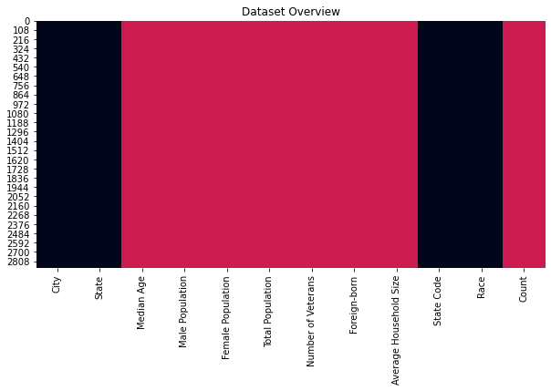

```
 Categerocial   Numerical   NaN
```

```python
dtf_overview(df_demographic, max_cat=10, figsize=(10,5))
```

### Step 3: Define the Data Model

#### 3.1 Conceptual Data Model

Map out the conceptual data model and explain why you chose that model

### 3.1 Schema for Immigration Analysis

[figure not shown]

- In this model, we don't consider the violet tables, like *i94cit_res, i94mode, temperature, demographic*. Otherwise, the analysis based on the fact table will be greatly affected.
- If we want to explore the relationship between temperature, urban population and immigration data, we can build another model

#### Fact Table

immigration - records with air transportation of immigrantion

- *cicid, year, month, airport_id, state_id, city, visa_id, admnum, longitude, latitude*

#### Dimension Table

i94port - code of destination city

i94addr - is where the immigrants resides in USA

i94visa - reason for immigration

airport - information of airports in USA

#### 3.2 Mapping Out Data Pipelines

List the steps necessary to pipeline the data into the chosen data model

### 3.2 Steps

1. Create tables (**create_tables.py**)
2. Read data, explore and clean data, save data (**etl.py**)
3. Copy data to PostgreSQL (**airflow/dags/dag.py**)
4. Insert to fact table (**airflow/dags/dag.py**)
5. Analyse the fact table (**immigration_analysis.ipynb**)

### Step 4: Run Pipelines to Model the Data

#### 4.1 Create the data model

Build the data pipelines to create the data model.

### **"airflow/dags/dag.py"**

#### 4.2 Data Quality Checks

Explain the data quality checks you'll perform to ensure the pipeline ran as expected. These could include:

- Integrity constraints on the relational database (e.g., unique key, data type, etc.)
- Unit tests for the scripts to ensure they are doing the right thing
- Source/Count checks to ensure completeness

Run Quality Checks

```python
# Perform quality checks here
# **"airflow/dags/dag.py"**

run_quality_checks = DataQualityOperator(
    task_id='Run_data_quality_checks',
    dag=dag,
    dq_checks=[
        {'check_sql': "SELECT COUNT(*) FROM immigration WHERE cicid is null", 'expected_result':0},
        {'check_sql': "SELECT COUNT(*) FROM immigrant WHERE admnum is null", 'expected_result':0},
        {'check_sql': "SELECT COUNT(*) FROM i94cit_res WHERE i94cit_res is null", 'expected_result':0},
        {'check_sql': "SELECT COUNT(*) FROM i94port WHERE i94port is null", 'expected_result':0},
        {'check_sql': "SELECT COUNT(*) FROM i94mode WHERE i94mode is null", 'expected_result':0},
        {'check_sql': "SELECT COUNT(*) FROM i94addr WHERE i94addr is null", 'expected_result':0},
        {'check_sql': "SELECT COUNT(*) FROM i94visa WHERE i94visa is null", 'expected_result':0},
        {'check_sql': "SELECT COUNT(*) FROM airport WHERE local_code is null", 'expected_result':0},
        {'check_sql': "SELECT COUNT(*) FROM temperature WHERE averagetemperature is null", 'expected_result':0},
        {'check_sql': "SELECT COUNT(*) FROM demographic WHERE total_population is null", 'expected_result':0}
    ],
    table=('immigration', 'immigrant', 'i94cit_res', 'i94port', 'i94mode', 'i94addr', 'i94visa', 'airport', 'temperature', 'demographic'),
    redshift_conn_id="redshift"
)
```

### **"airflow/plugins/operators/data_quality.py"**

The operator's main functionality is to receive one or more SQL based test cases along with the expected results and execute the tests.

#### 4.3 Data dictionary

Create a data dictionary for your data model. For each field, provide a brief description of what the data is and where it came from. You can include the data dictionary in the notebook or in a separate file.

**"Data_Dictionary.xlsx"**

### Step 5: Complete Project Write Up

- Clearly state the rationale for the choice of tools and technologies for the project.
- Propose how often the data should be updated and why.
- Write a description of how you would approach the problem differently under the following scenarios:
  - The data was increased by 100x.
  - The data populates a dashboard that must be updated on a daily basis by 7am every day.
  - The database needed to be accessed by 100+ people.

### 1. tools and technologies

Pandas - We use it to read and wirte files to dataframe.

Numpy, Matplotlib - We can use them to analyse the immigration and plot.

Pyspark - When we read a large amount of data, pandas is no longer applicable. At this time, we need to use pyspark.

### 2.

Monthly. Because most of our analysis is done on a monthly basis.

### 3.

- The data was increased by 100x.

When the amount of data is small, we can use the traditional way to process it on the personal computer. Due to the scalability of redshift, we can also directly use redshift to store data, so that even if the data was increased by 100x, we don't have to worry about insufficient storage space, and use Hadoop cluster to calculate and analyze.

- The data populates a dashboard that must be updated on a daily basis by 7am every day.

Airflow is a programmable, scheduling and monitoring workflow platform. Airflow provides rich command-line tools for system control, and its web management interface can also facilitate the control and scheduling of tasks, and real-time monitor the operation status of tasks. We can use airflow to schedule the execution time of tasks.

- The database needed to be accessed by 100+ people.

Traditional relational database can be contentedly used. However, in order to improve the access and reading efficiency, we can choose NoSQL, such as Cassandra.